# eda

Importing necessary Libraries we'll use for **Data Analysis** and **Visualization**

```python
import pandas as pd
import numpy as np
import matplotlib.pyplot as plt
import seaborn as sns

# Set visualization styles
sns.set(style="whitegrid")
plt.rcParams["figure.figsize"] = (10, 6)
```

Then we should load the Dataset we want to analyze ('LoanExport.csv').

```python
# Load the preprocessed data
data = pd.read_csv("../MortgageLoanExport/LoanExport.csv")

# Display the first few rows of the dataset
data.head()
```

|  | CreditScore | FirstPaymentDate | FirstTimeHomebuyer | MaturityDate | MSA | MIP | Units | Occupancy | OCLTV | DTI | ... | PostalCode | LoanSeqNum | LoanPurpose | OrigLoanTerm | NumBorrowers | SellerName | ServicerName | EverDelinquent | MonthsDelinquent | MonthsInRepayment |
| --- | --- | --- | --- | --- | --- | --- | --- | --- | --- | --- | --- | --- | --- | --- | --- | --- | --- | --- | --- | --- | --- |
| 0 | 0 | 199902 | N | 202901 | 16974 | 25 | 1 | O | 89 | 27 | ... | 60400 | F199Q1268030 | P | 360 | 2 | FL | WASHINGTONMUTUALBANK | 0 | 0 | 52 |
| 1 | 0 | 199902 | N | 202901 | 19740 | 0 | 1 | O | 73 | 17 | ... | 80200 | F199Q1015092 | N | 360 | 1 | FT | CHASEHOMEFINANCELLC | 0 | 0 | 144 |
| 2 | 0 | 199902 | N | 202901 | 29940 | 0 | 1 | O | 75 | 16 | ... | 66000 | F199Q1266886 | N | 360 | 2 | FL | WASHINGTONMUTUALBANK | 0 | 0 | 67 |
| 3 | 0 | 199902 | N | 202901 | 31084 | 0 | 1 | O | 76 | 14 | ... | 90700 | F199Q1178167 | N | 360 | 2 | GM | GMACMTGECORP | 0 | 0 | 35 |
| 4 | 0 | 199902 | N | 202901 | 35644 | 0 | 1 | O | 78 | 18 | ... | 7600 | F199Q1178517 | N | 360 | 2 | GM | GMACMTGECORP | 0 | 0 | 54 |

5 rows × 28 columns

Now let's inspect the dataset to understand its structure,types,and general content.

```python
# Check the data types and missing values
data.info()

# Get a summary of the dataset's numeric columns
data.describe()

# Check for missing values
missing_values = data.isnull().sum()
print("Missing Values:\n", missing_values[missing_values > 0])
```

```
<class 'pandas.core.frame.DataFrame'>
RangeIndex: 291451 entries, 0 to 291450
Data columns (total 28 columns):
 #   Column              Non-Null Count   Dtype
---  ------              --------------   -----
 0   CreditScore         291451 non-null  int64
 1   FirstPaymentDate    291451 non-null  int64
 2   FirstTimeHomebuyer  291451 non-null  object
 3   MaturityDate        291451 non-null  int64
 4   MSA                 291451 non-null  object
 5   MIP                 291451 non-null  int64
 6   Units               291451 non-null  int64
 7   Occupancy           291451 non-null  object
 8   OCLTV               291451 non-null  int64
 9   DTI                 291451 non-null  int64
```

[output cut: 23 more lines]

Since the target feature is 'EverDeliquent', we should **understand its distribution**.

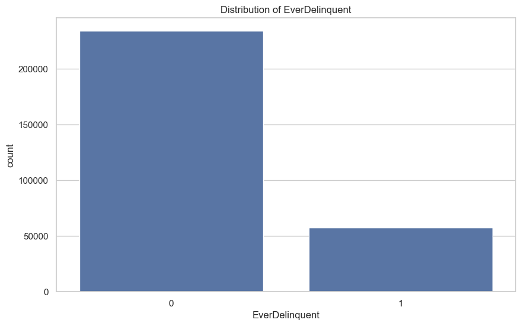

```
Class Proportion:
 EverDelinquent
0    0.802152
1    0.197848
Name: proportion, dtype: float64
```

```python
# Distribution of the target variable 'EverDelinquent'
sns.countplot(x='EverDelinquent', data=data)
plt.title("Distribution of EverDelinquent")
plt.show()

# Display the proportion of each class in the target variable
class_proportion = data['EverDelinquent'].value_counts(normalize=True)
print("Class Proportion:\n", class_proportion)
```

And now we'll analyse numerical features, explore their distribution and check for outliers.

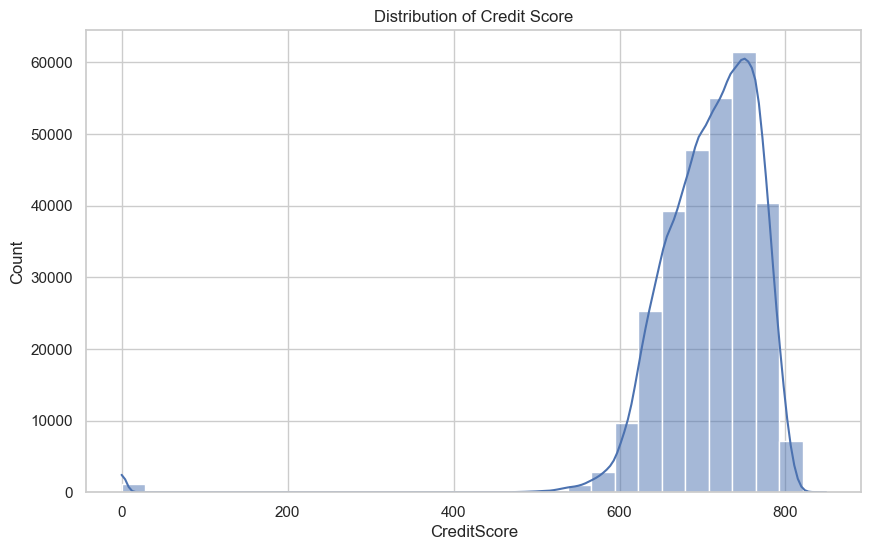

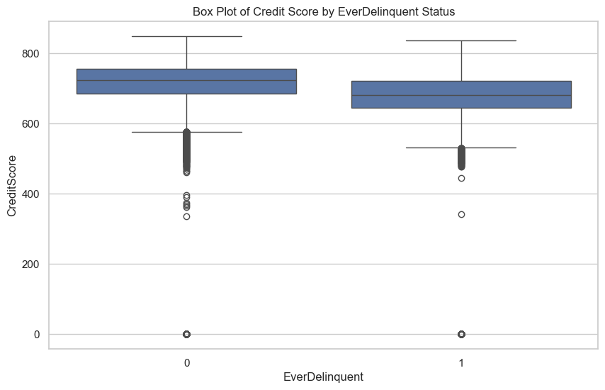

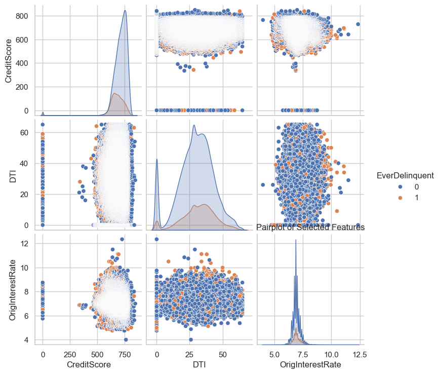

```python
# Histogram of a numeric feature (e.g., CreditScore)
sns.histplot(data['CreditScore'], kde=True, bins=30)
plt.title("Distribution of Credit Score")
plt.show()

# Boxplot to detect outliers in a numeric feature (e.g., CreditScore)
sns.boxplot(x='EverDelinquent', y='CreditScore', data=data)
plt.title("Box Plot of Credit Score by EverDelinquent Status")
plt.show()

# Pairplot for selected numeric features
sns.pairplot(data[['CreditScore', 'DTI', 'OrigInterestRate', 'EverDelinquent']], hue='EverDelinquent')
plt.title("Pairplot of Selected Features")
plt.show()
```

Now that we've analyzed the numerical features, let's analyze the categorical ones and examine their relationship with the target variable.